# Modelling and Predicting Exercise Type from Human Activity Recognition Data

AO

26/08/2020

## Introduction and Summary

Human Activity Recognition is a key research area. People regularly quantify how much of a particular activity they do, but not how well they do it. In this project, we use data from accelerometers on the belt, forearm and dumbell of 6 particupants to predict the manner in which they did the exercise.

The outcome variable to be predicted is classe, a factor variable.

## Loading packages and reading the data

```r
library(tidyverse)
library(caret)
library(rattle)
```

```r
library(e1071)
library(rpart)
library(rpart.plot)
```

We check to see if the files exist and download them if not.

```r
if (!file.exists("pml-training.csv")) {
  download.file("https://d396qusza40orc.cloudfront.net/predmachlearn/pml-training.csv",
  destfile = "pml-training.csv")
}
if (!file.exists("pml-testing.csv")) {
  download.file("https://d396qusza40orc.cloudfront.net/predmachlearn/pml-testing.csv",
  destfile = "pml-testing.csv")
}
training_data <- read.csv("pml-training.csv",na.strings=c("NA","#DIV/0!", ""))
testing_data <- read.csv("pml-testing.csv",na.strings=c("NA","#DIV/0!", ""))
```

Viewing the structure of the training data

```r
str(training_data)
```

[output not shown]

Our training dataset has 19622 observations and 160 variables. Let’s reduce the variable number if possible.

```r
dim(training_data)
```

```
## [1] 19622   160
```

```r
dim(testing_data)
```

```
## [1]  20 160
```

## Data Processing

There are a lot of variables with primarily NAs. We remove these.

```r
table(is.na(training_data))
```

```
##
##   FALSE    TRUE
## 1214418 1925102
```

Removing variables with all missing data

```r
training_data <- training_data[,colSums(is.na(training_data)) == 0]
testing_data <- testing_data[,colSums(is.na(testing_data)) == 0]
```

Removing variables with variance near zero

```r
low_var <- nearZeroVar(training_data, saveMetrics = TRUE)
trainingData <- training_data[,low_var$low_var == "FALSE"]
training_data$classe <- as.factor(training_data$classe)
```

Removing the first 7 variables after viewing column names.

```r
training_data <- training_data[,-c(1:7)]
testing_data <- testing_data[, -c(1:7)]
```

We have reduced variable number from 160 to 53.

```r
dim(training_data)
```

```
## [1] 19622    53
```

Let’s have a look at our data by the prediction variable

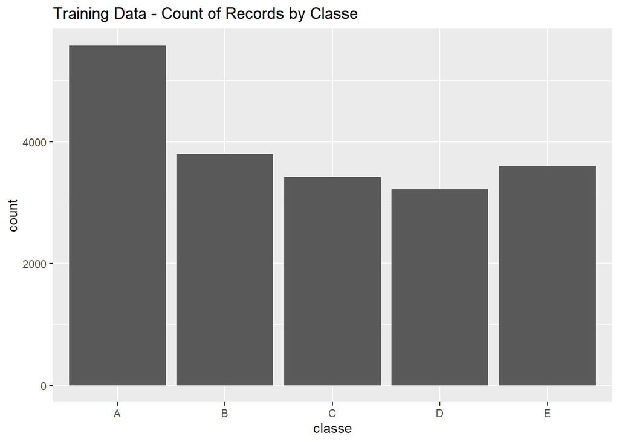

```r
training_data %>% ggplot(aes(x = classe)) +
  geom_bar() +
  ggtitle("Training Data - Count of Records by Classe")
```

Classe A has the most recordings but as they are all within the same order of magnitude it should not impact our model.

## Data Partitioning for Cross-Validation

Let’s split the training data into a training set to train the model (75% of the data), and a test set to predict the out of sample error for cross-validation. We will split on the variable of interest (classe). Once the model is optimised, it will be used on the original testing data.

```r
set.seed(123)
inTrain <- createDataPartition(y = training_data$classe, p=.75, list = FALSE) #Partitioning our training data for cross-validation
training <- training_data[inTrain, ]
testing <- training_data[-inTrain, ]
```

## Model Building and Additional Cross-Validation

We first try a random forest model as they are usually one of the top performing models.

We allow for parallel processing. We accept there might be some over-fitting with a random forest model, and will also try a decision tree later on.

Let’s build this model with re-sampling method and 5-fold cross-validation.

```r
set.seed(123)
rFModel <- train(classe ~., method = "rf", data = training,
                 trControl = trainControl(method = "cv", number = 5), #5-fold cross-validation
                 prox = TRUE, allowParallel = TRUE)
```

Let’s look at our random forest model

```r
rFModel
```

```
## Random Forest
##
## 14718 samples
##    52 predictor
##     5 classes: 'A', 'B', 'C', 'D', 'E'
##
## No pre-processing
## Resampling: Cross-Validated (5 fold)
## Summary of sample sizes: 11775, 11773, 11774, 11774, 11776
## Resampling results across tuning parameters:
##
##   mtry  Accuracy   Kappa
##    2    0.9921186  0.9900297
##   27    0.9918469  0.9896872
##   52    0.9853928  0.9815194
##
## Accuracy was used to select the optimal model using the largest value.
## The final value used for the model was mtry = 2.
```

We will assess the accuracy of the random forest model in the next section, but now let’s also look at a decision tree model. Tree models iteratively split variables into groups and are easy to interpret.

```r
set.seed(123)
dtModel <- rpart(classe ~ ., data=training, method="class")
```

[figure not shown]

```r
fancyRpartPlot(dtModel)
```

## Model Accuracy and Out of Sample Error

We test our model on the partitioned test data sub-set from our original training set with a confusion matrix.

```r
rFModel_test <- predict(rFModel, testing)
confusionMatrix(testing$classe,rFModel_test)
```

```
## Confusion Matrix and Statistics
##
##           Reference
## Prediction    A    B    C    D    E
##          A 1395    0    0    0    0
##          B    1  946    2    0    0
##          C    0    8  847    0    0
##          D    0    0   15  789    0
##          E    0    0    0    2  899
##
## Overall Statistics
##
##                Accuracy : 0.9943
##                  95% CI : (0.9918, 0.9962)
##     No Information Rate : 0.2847
##     P-Value [Acc > NIR] : < 2.2e-16
##
##                   Kappa : 0.9928
##
##  Mcnemar's Test P-Value : NA
##
## Statistics by Class:
##
##                      Class: A Class: B Class: C Class: D Class: E
## Sensitivity            0.9993   0.9916   0.9803   0.9975   1.0000
## Specificity            1.0000   0.9992   0.9980   0.9964   0.9995
## Pos Pred Value         1.0000   0.9968   0.9906   0.9813   0.9978
## Neg Pred Value         0.9997   0.9980   0.9958   0.9995   1.0000
## Prevalence             0.2847   0.1945   0.1762   0.1613   0.1833
## Detection Rate         0.2845   0.1929   0.1727   0.1609   0.1833
## Detection Prevalence   0.2845   0.1935   0.1743   0.1639   0.1837
## Balanced Accuracy      0.9996   0.9954   0.9892   0.9969   0.9998
```

```r
rf_accuracy <- confusionMatrix(testing$classe, rFModel_test)$overall[1]
rf_accuracy
```

```
##  Accuracy
## 0.9942904
```

```r
out_of_sample_error <- 1- rf_accuracy
out_of_sample_error
```

```
##    Accuracy
## 0.005709625
```

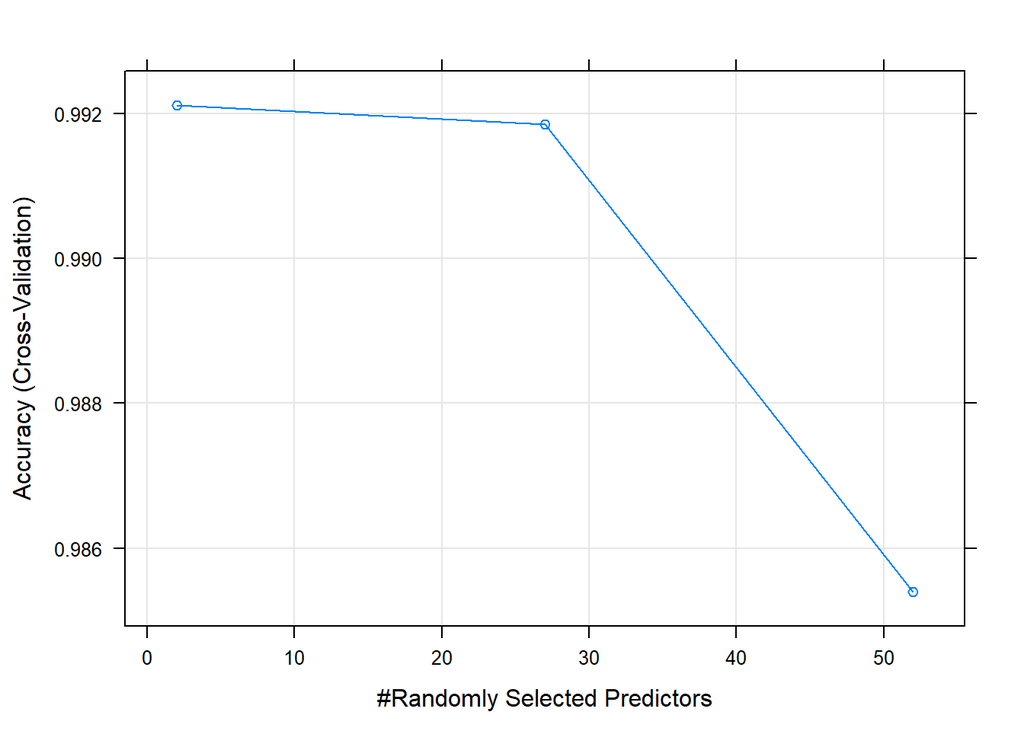

```r
plot(rFModel)
```

The prediction accuracy is (rounded to three decimal places) 99.429% and the out of sample error is 0.571%. This is a high level of accuracy with a 95% confidence interval that the accuracy falls between 99.18% and 99.62%.

Let’s look at the thirty most important variables for our model.

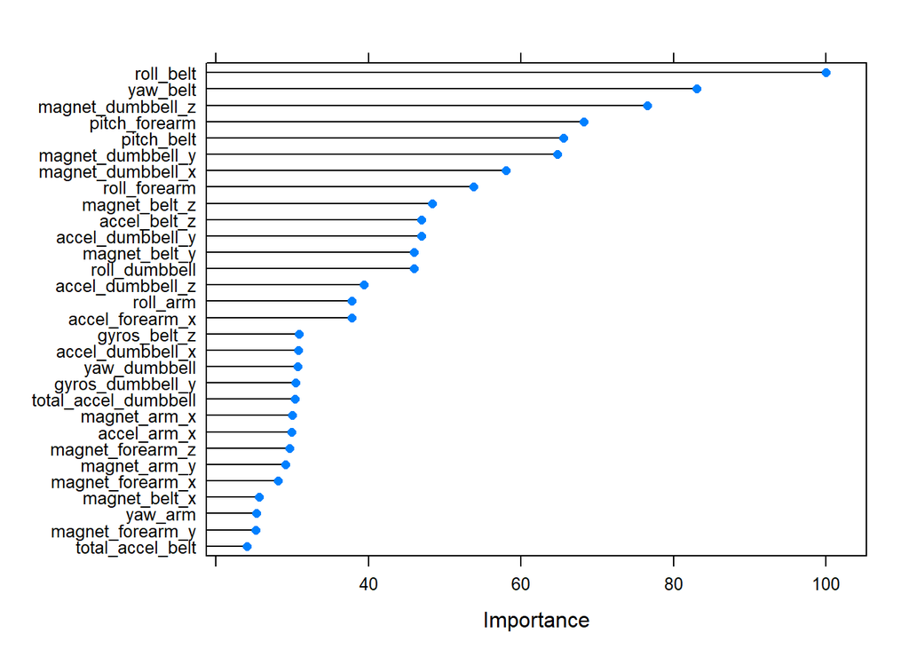

```r
plot(varImp(rFModel), top = 30)
```

Let’s look at our decision tree model with a confusion matrix

```r
dtModel_test <- predict(dtModel, testing, type = "class")
confusionMatrix(testing$classe, dtModel_test)
```

```
## Confusion Matrix and Statistics
##
##           Reference
## Prediction    A    B    C    D    E
##          A 1304   28   25   18   20
##          B  185  479  125   69   91
##          C   31   34  689   37   64
##          D  102   16  130  477   79
##          E   45   29  109   50  668
##
## Overall Statistics
##
##                Accuracy : 0.7376
##                  95% CI : (0.725, 0.7498)
##     No Information Rate : 0.3399
##     P-Value [Acc > NIR] : < 2.2e-16
##
##                   Kappa : 0.6659
##
##  Mcnemar's Test P-Value : < 2.2e-16
##
## Statistics by Class:
##
##                      Class: A Class: B Class: C Class: D Class: E
## Sensitivity            0.7822  0.81741   0.6391  0.73272   0.7245
## Specificity            0.9719  0.89115   0.9566  0.92311   0.9415
## Pos Pred Value         0.9348  0.50474   0.8058  0.59328   0.7414
## Neg Pred Value         0.8966  0.97295   0.9039  0.95756   0.9365
## Prevalence             0.3399  0.11949   0.2198  0.13275   0.1880
## Detection Rate         0.2659  0.09768   0.1405  0.09727   0.1362
## Detection Prevalence   0.2845  0.19352   0.1743  0.16395   0.1837
## Balanced Accuracy      0.8771  0.85428   0.7979  0.82792   0.8330
```

The accuracy for this decision tree model is 73.76% (95% confidence interval that it lies between 72.5% and 74.98%), ar lower than with the random forest approach. This would yield a much higher out of sample error. We will therefore disregard this model and proceed with the random forest model.

## Prediction

Our random forest model is sufficiently accurate to run on our original testing data. Results are hidden here to adhere to Coursera’s honour code.

```r
quiz_prediction <- predict(rFModel, testing_data)
quiz_prediction
```

## Conclusion

We used two types of models to predict the exercise type and found random forest to give us predictions with a high level of accuracy.